# One formula, three backends — autodiff vanna & volga

The same Expr runs in Polars, differentiates in JAX, and renders to LaTeX

This is Schenberg’s headline trick. A pricing formula is a small **symbolic expression** (`Expr`), and the *same* tree is interpreted three ways:

| backend | function | what you get |
| --- | --- | --- |
| Polars | `compile_polars` | the lazy column that runs |
| JAX | `grad`, `compile_numeric` | analytic sensitivities, to any order |
| LaTeX | `to_latex` | math derived from the IR — it can’t drift from what runs |

So the Greeks are not a second, hand-typed copy of the formula that silently rots. They *are* the formula, differentiated. Below we get **delta** and **vega** from the lib’s `grad`, then reach **vanna** (∂²/∂S∂σ) and **volga** (∂²/∂σ²) by handing the very same IR to JAX — and reconcile every one against finite differences of the same expression.

**Imports**

```python
import numpy as np
import polars as pl
import matplotlib.pyplot as plt
import jax
import jax.numpy as jnp
jax.config.update("jax_enable_x64", True)

from schenberg import var, lit, exp, log, sqrt, normal_cdf, compile_polars, compile_numeric, grad, to_latex

plt.rcParams.update({"figure.dpi": 110, "axes.grid": True, "grid.alpha": 0.3})
```

## 1. Build the price as one expression

`S`, `K`, `r`, `sigma`, `T` are `var` leaves; everything else is the lib’s small operator set.

```python
S, K, r, sigma, T = (var(n) for n in ("S", "K", "r", "sigma", "T"))

d1 = (log(S / K) + (r + 0.5 * sigma**2) * T) / (sigma * sqrt(T))
d2 = d1 - sigma * sqrt(T)
C = S * normal_cdf(d1) - K * exp(-r * T) * normal_cdf(d2)
```

The LaTeX below is rendered straight from the IR — no string was typed by hand:

```python
print(f"$$ d_1 = {to_latex(d1)} $$\n")
print(f"$$ d_2 = {to_latex(d2)} $$\n")
print(f"$$ C = {to_latex(C)} $$\n")
```

$$d_1 = \frac{\ln\left(\frac{\mathrm{S}}{\mathrm{K}}\right) + \left(\mathrm{r} + 0.5 \cdot \mathrm{sigma}^{2}\right) \cdot \mathrm{T}}{\mathrm{sigma} \cdot \sqrt{\mathrm{T}}}$$

$$d_2 = \frac{\ln\left(\frac{\mathrm{S}}{\mathrm{K}}\right) + \left(\mathrm{r} + 0.5 \cdot \mathrm{sigma}^{2}\right) \cdot \mathrm{T}}{\mathrm{sigma} \cdot \sqrt{\mathrm{T}}} - \mathrm{sigma} \cdot \sqrt{\mathrm{T}}$$

$$C = \mathrm{S} \cdot \Phi\left(\frac{\ln\left(\frac{\mathrm{S}}{\mathrm{K}}\right) + \left(\mathrm{r} + 0.5 \cdot \mathrm{sigma}^{2}\right) \cdot \mathrm{T}}{\mathrm{sigma} \cdot \sqrt{\mathrm{T}}}\right) - \mathrm{K} \cdot e^{-\mathrm{r} \cdot \mathrm{T}} \cdot \Phi\left(\frac{\ln\left(\frac{\mathrm{S}}{\mathrm{K}}\right) + \left(\mathrm{r} + 0.5 \cdot \mathrm{sigma}^{2}\right) \cdot \mathrm{T}}{\mathrm{sigma} \cdot \sqrt{\mathrm{T}}} - \mathrm{sigma} \cdot \sqrt{\mathrm{T}}\right)$$

## 2. The same `C` runs in Polars

```python
env_cols = pl.DataFrame(
    {"S": [100.0, 110.0], "K": [100.0, 100.0], "r": [0.05, 0.05],
     "sigma": [0.20, 0.20], "T": [1.0, 1.0]}
).lazy()

env_cols.select(price=compile_polars(C)).collect()
```

shape: (2, 1)

| price f64 |
| --- |
| 10.450576 |
| 17.662954 |

## 3. First-order Greeks from `grad`

`grad(C, "S")` returns an *elementwise analytic derivative* via JAX. Delta is ∂C/∂S; vega is ∂C/∂σ.

```python
env = {"S": np.array([100.0]), "K": np.array([100.0]), "r": np.array([0.05]),
       "sigma": np.array([0.20]), "T": np.array([1.0])}

delta = grad(C, "S")(env)
vega = grad(C, "sigma")(env)
print(f"delta = {float(delta[0]):.6f}    vega = {float(vega[0]):.6f}")
```

```
delta = 0.636836    vega = 37.523874
```

## 4. Second-order Greeks — hand the IR to JAX

`compile_numeric(C)` turns the IR into a plain numeric function, so *any* order of sensitivity is just `jax.grad` composed. Vanna = ∂²C/∂S∂σ, volga = ∂²C/∂σ².

```python
price_fn = compile_numeric(C)


def price_scalar(S_, K_, r_, sig_, T_):
    return price_fn({"S": S_, "K": K_, "r": r_, "sigma": sig_, "T": T_}, jnp)


# argnums: 0=S, 3=sigma
d_dS = jax.grad(price_scalar, argnums=0)
d_dSig = jax.grad(price_scalar, argnums=3)
vanna_fn = jax.vmap(jax.grad(d_dSig, argnums=0))   # d(vega)/dS
volga_fn = jax.vmap(jax.grad(d_dSig, argnums=3))   # d(vega)/dsigma


def at(**kw):
    return tuple(jnp.asarray(kw[k], dtype=float) for k in ("S", "K", "r", "sigma", "T"))


pt = dict(S=[100.0], K=[100.0], r=[0.05], sigma=[0.20], T=[1.0])
vanna = vanna_fn(*at(**pt))
volga = volga_fn(*at(**pt))
print(f"vanna = {float(vanna[0]):.6f}    volga = {float(volga[0]):.6f}")
```

```
vanna = -0.281480    volga = 9.851784
```

## 5. Reconcile every Greek against finite differences

Both sides walk the *same* expression, so agreement is a real correctness check on the autodiff path — not a comparison of two different formulas.

```python
def fd1(fn, x, h):     # central first difference
    return (fn(x + h) - fn(x - h)) / (2 * h)

def fd2(fn, x, h):     # central second difference
    return (fn(x + h) - 2 * fn(x) + fn(x - h)) / h**2

S0, K0, r0, sig0, T0 = 100.0, 100.0, 0.05, 0.20, 1.0
P = lambda **kw: float(price_fn({**dict(S=S0, K=K0, r=r0, sigma=sig0, T=T0), **kw}, np))

delta_fd = fd1(lambda s: P(S=s), S0, 1e-3)
vega_fd = fd1(lambda v: P(sigma=v), sig0, 1e-4)
volga_fd = fd2(lambda v: P(sigma=v), sig0, 1e-3)
# vanna by bumping spot inside a vega finite difference
vanna_fd = (fd1(lambda v: P(S=S0 + 1e-2, sigma=v), sig0, 1e-4)
            - fd1(lambda v: P(S=S0 - 1e-2, sigma=v), sig0, 1e-4)) / (2 * 1e-2)

rows = [
    ("delta  ∂C/∂S",   float(delta[0]), delta_fd),
    ("vega   ∂C/∂σ",   float(vega[0]),  vega_fd),
    ("vanna  ∂²C/∂S∂σ", float(vanna[0]), vanna_fd),
    ("volga  ∂²C/∂σ²",  float(volga[0]), volga_fd),
]
pl.DataFrame(
    {
        "greek": [r[0] for r in rows],
        "autodiff": [r[1] for r in rows],
        "finite_diff": [r[2] for r in rows],
        "abs_error": [abs(r[1] - r[2]) for r in rows],
    }
)
```

shape: (4, 4)

| greek str | autodiff f64 | finite_diff f64 | abs_error f64 |
| --- | --- | --- | --- |
| "delta ∂C/∂S" | 0.636836 | 0.636836 | 9.0907e-11 |
| "vega ∂C/∂σ" | 37.523874 | 37.523873 | 3.0442e-7 |
| "vanna ∂²C/∂S∂σ" | -0.28148 | -0.28148 | 1.0379e-8 |
| "volga ∂²C/∂σ²" | 9.851784 | 9.852065 | 0.000281 |

## 6. Vanna & volga across moneyness

Because the Greeks are functions, plotting a smile-relevant view is one `vmap`.

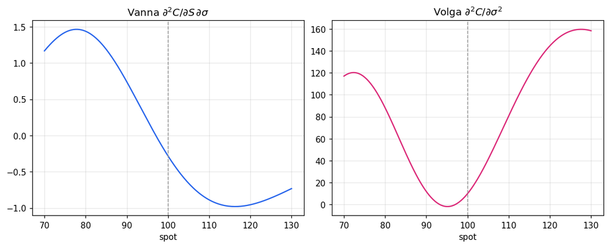

```python
S_grid = np.linspace(70.0, 130.0, 240)
args = at(S=S_grid, K=np.full_like(S_grid, 100.0), r=np.full_like(S_grid, 0.05),
          sigma=np.full_like(S_grid, 0.20), T=np.full_like(S_grid, 1.0))
vanna_curve = np.asarray(vanna_fn(*args))
volga_curve = np.asarray(volga_fn(*args))

fig, ax = plt.subplots(1, 2, figsize=(10, 4), constrained_layout=True)
ax[0].plot(S_grid, vanna_curve, color="#2563eb"); ax[0].set_title(r"Vanna $\partial^2 C/\partial S\,\partial\sigma$")
ax[1].plot(S_grid, volga_curve, color="#db2777"); ax[1].set_title(r"Volga $\partial^2 C/\partial \sigma^2$")
for a in ax:
    a.axvline(100.0, color="0.6", ls="--", lw=1); a.set_xlabel("spot")
plt.show()
```

No SymPy, no algebra by hand, no second copy of the formula to keep in sync — the sensitivities fall out of the one expression you already wrote.